# FitBit Prediction

D Lynch

27 September 2017

## Loading the data

Data read in from csv

```r
library(dplyr)

pml_training <- read.csv(
    '../FBit_Data/pml-training.csv', header = TRUE, na.strings = 'NA'
    )

pml_testing <- read.csv(
    '../FBit_Data/pml-testing.csv', header = TRUE, na.strings = 'NA'
    )
```

## Preprocessing

After a quick look at both files, it was clear that there were many NA columns in the testing data. These NA columns were removed from both data sets

```r
# Apply loop returns TRUE for the NA rows
# included ! to convert True to False and vice versa
NaCols <- !apply(pml_testing, 2, anyNA)

pml_training <- pml_training [,NaCols]
pml_testing <- pml_testing [,NaCols]
```

I read on the forums that there was a strong corrlolation with time and classe. The plot below shows the data for one user, and time against index with classe highlighted by colour

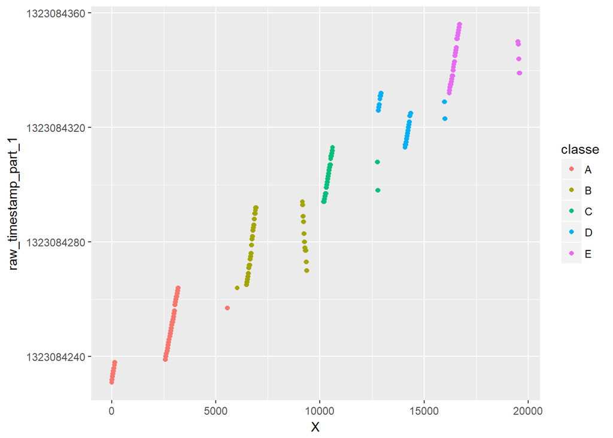

```r
library(ggplot2)
User1 <- pml_training[pml_training$user_name=='carlitos',]
ggplot (data = User1, aes(x = X, y = raw_timestamp_part_1, colour = classe)) + geom_point()
```

Obviously this is not what we want to show, so all variable related to time, and index are removed:

```r
pml_training <- pml_training %>%
    subset( select = -c(X, raw_timestamp_part_1, raw_timestamp_part_2,
                        cvtd_timestamp, new_window, num_window))

# Apply to the test data too
pml_testing <- pml_testing %>%
    subset( select = -c(X, raw_timestamp_part_1, raw_timestamp_part_2,
                        cvtd_timestamp, new_window, num_window))

# Testing data also has a problemID column at the end, remove this
pml_testing <- subset(pml_testing, select = -c(problem_id))
```

And a quick check over the data:

```r
# Check for any NA's in data
anyNA(apply(pml_training, 2, anyNA))
```

```
## [1] FALSE
```

There are no Na’s in the data frame

```r
# Check the calsses of each col
lapply(pml_training, class)%>%unlist%>%table
```

```
## .
##  factor integer numeric
##       2      25      27
```

As expected, there are 2 factor columns (which are user_name and classe) and the rest are integer or numeric.

## Building the model

Split the training data up into building and validating data

```r
# I plan using an Ensembling method, hence the 2 build sets, and validation
set.seed (1234)
library(caret)

inBuild <- createDataPartition(pml_training$classe, p = .75, list = FALSE)
building <- pml_training[inBuild,]
validating <- pml_training[-inBuild,]
```

Create the models. I choose to do a random forest model, because I hope that I will get high accuracy. I looked into speeding up the required time, and found a like to this site from the Coursera forums:

https://github.com/lgreski/datasciencectacontent/blob/master/markdown/pml-randomForestPerformance.md

However, at fist the `train` function still gave an error. From researching online, it turns out that caret had a bug when using multiple cores. The bug has been resolved on the github version of caret, but the CRAN version (caret_6.0-77) still contains it. `devtools::install_github('topepo/caret/pkg/caret')` fixed the issue

```r
library(parallel)
library(doParallel)
cluster <- makeCluster(detectCores() - 1) # convention to leave 1 core for OS
registerDoParallel(cluster)

fitControl <- trainControl(method = "cv",
                           number = 10,
                           allowParallel = TRUE)

st <- Sys.time()
modRF <- train(classe~., method = 'rf', data = building, trControl = fitControl)
st <- Sys.time() - st
print(st)
```

```
## Time difference of 12.47032 mins
```

```r
stopCluster(cluster)
registerDoSEQ()
```

## Results

Check the in sample error

```r
predInSample <- predict(modRF, building)
cmInSamp <- confusionMatrix(predInSample, building$classe)
cmInSamp$table
```

```
##           Reference
## Prediction    A    B    C    D    E
##          A 4185    0    0    0    0
##          B    0 2848    0    0    0
##          C    0    0 2567    0    0
##          D    0    0    0 2412    0
##          E    0    0    0    0 2706
```

```r
cmInSamp$overall
```

```
##       Accuracy          Kappa  AccuracyLower  AccuracyUpper   AccuracyNull
##      1.0000000      1.0000000      0.9997494      1.0000000      0.2843457
## AccuracyPValue  McnemarPValue
##      0.0000000            NaN
```

Wow! Perfect! This is actaully a little worrying, as there are 2 explanations for this:

- Excellant modelling
- Over fitting

I will know if over fitting was the issue, if the out of sample error is very high

```r
predOutSample <- predict(modRF, validating)
cmOutSamp <- confusionMatrix(predOutSample, validating$classe)
cmOutSamp$table
```

```
##           Reference
## Prediction    A    B    C    D    E
##          A 1395    7    0    0    0
##          B    0  939    9    1    0
##          C    0    3  844    8    2
##          D    0    0    2  795    1
##          E    0    0    0    0  898
```

```r
cmOutSamp$overall
```

```
##       Accuracy          Kappa  AccuracyLower  AccuracyUpper   AccuracyNull
##      0.9932708      0.9914867      0.9905626      0.9953635      0.2844617
## AccuracyPValue  McnemarPValue
##      0.0000000            NaN
```

## Test sample

Now to apply it to the test sample:

```r
predTest <- predict(modRF, pml_testing)
predTest
```

```
##  [1] B A B A A E D B A A B C B A E E A B B B
## Levels: A B C D E
```

I entered the results into the quiz and passed with 100%, so we can conlude that the random forest has done a really good job in this case.

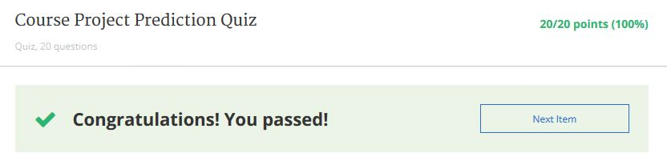

Screen shot from Coursera